# Sexual Dimorphism and Sexual Selection Tutorial

Elizabeth Houghton and Kirsten Palmier

## Tutorial learning objectives

In this tutorial you will explore:

- Whether sexual dimorphism is present in a population of Tree Swallows found in Long Point, Ontario
- Life history traits of Tree Swallow
- Trade offs between the number of clutches a bird may have and the number of eggs in each clutch
- How the sampled population of Tree Swallow’s birth rates have changed over time

## Background of datasets

This is a tutorial to get you familiar with R and explore ecological concepts through a Tree Swallow nest productivity dataset. Before we jump into the weeds, let’s get to know our dataset!

Additionally, in 2021, this dataset was quality checked and made open access by Jonathan Diamond through a Data Rescue internship with the Living Data Project, an initiative through the Canadian Institute of Ecology and Evolution that rescues legacy datasets.

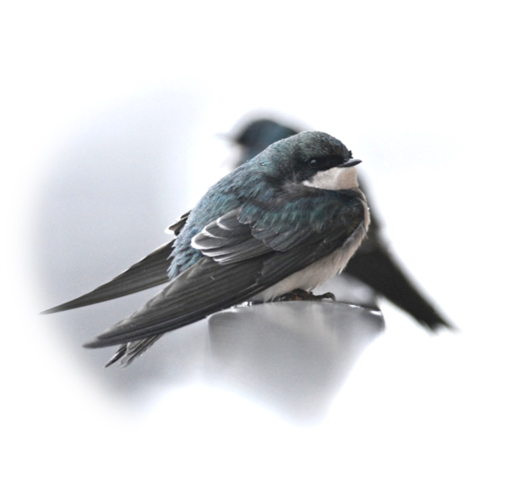

Through Bird Studies Canada, Long Point Bird Observatory monitored three nest box “colonies” of Tree Swallows at Long Point, two on the “mainland” near Port Rowan (at the Port Rowan sewagelagoons and adjacent to agricultural land at mudd creek) and the third at the tip of the Point.

[figure not shown]

### The Point

This colony was established in its present location in 1969. The nest boxes are located about 1 kmwest of the Tip of the point and are arranged 24.4m apart in a grid of numbered (north-south) rows and lettered (east-west) columns. Each box is designated by its position, so box 10G is in row 10 and column G. At the present time the rows in use are 1-19 and the letters are D-K, but many positions are unfilled and there are a total of 64 boxes.

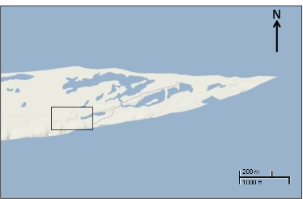

The Point colony area. Location of bird boxes outlined in black.

### The Sewage Lagoon

This colony was first established in 1977 and has since been expanded to a total of 77 boxes. The boxes are in two rows around the lagoon embankment, as well as across the street in a small cluster of 5 boxes.

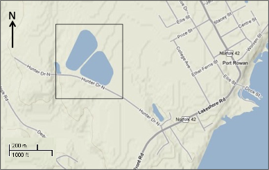

Sewage Lagoon colony area. Location of bird boxes outlined in black.

### Mud Creek

Established in 1987, the Mud Creek site is located 3.25 km north-northeast of Sewage Lagoon and contains 80 nest boxes. The habitat is an open, uncultivated field adjacent to a small woodlot.

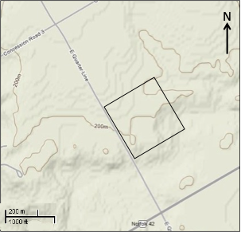

Mud Creek colony area. Location of bird boxes outlined in black.

For this tutorial we will be looking at the banding dataset which adults were trapped sometime between the first young hatch and when they were 12 days old. All adult birds are banded, unless previously banded. It was also recorded if the bird had a brood patch (BP) or cloacal protuberance (CP). Plumage color was recorded as blue (BLU), Brown (BRN), or Intermediate (INT). Furthermore, plumage categories and age/sex designations were assigned and a variety of size measurements were taken:

*Plumage Categories*

- BLU birds (ASY) – More than 90% of the upper parts iridescent blue-green
- INT birds (AHY) – More than 50% up to 90% of upper parts iridescent blue-green (remainder dull brown or brown tinged with green)
- BRN birds (SY) – Up to 50% of upper parts iridescent blue-green (remainder > 50% dull brown or brown tinged with green)

*Sex Categories*

- Male = M
- Female = F

*Measurements of Size and Weight*

- Wing chord length (mm) = wing_chord
- Wing chord flat (mm) = wing_flat
- Tail length (mm) = tail
- p_9 = primary feather length

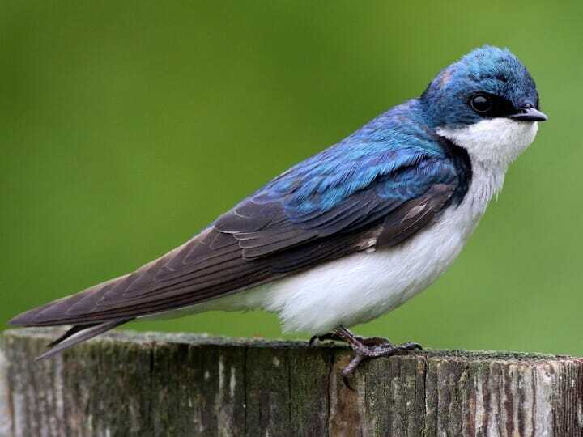

Adults are blue-green above with white below with blacking flight feathers. Photo courtesy of Max Nootbaar from the Macaulay Library.

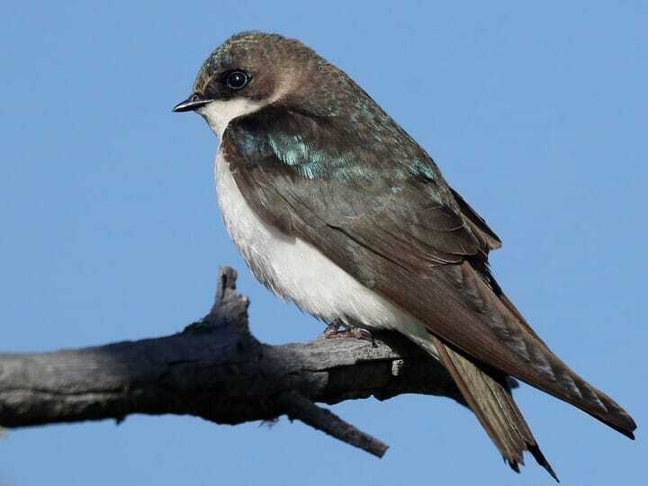

First year females may be brownish above with hints of blue-green; adult females can be nearly blue-green as males. Photo courtesy of Matt Davis from the Macaulay Library.

## Importing data and packages

In this tutorial, we will be working with Tree Swallow data collected by Bird Studies Canada, Long Point Bird Observatory as well as a few additional packages. Run the following code to import the required packages and pull in the dataset that we will be working with throughout this tutorial.

```r
library(dplyr)
library(ggplot2)
library(tidyr)
library(lubridate)
library(reshape)
library(readr)
library(ggpubr)
# Here we are pulling the actual datasets into R
banding <- read.csv("TRES/banding_final.csv")
banding_nest <- read.csv("TRES/banding_nest_final.csv")
nest <- read.csv("TRES/nest_final.csv")
```

```r
# Now, we want to make sure the class of our data is correct before we move forward:
str(banding)
```

```
## 'data.frame':    1602 obs. of  13 variables:
##  $ band_or_recapture: chr  "R" "R" "R" "R" ...
##  $ band_number      : num  1831 1881 2171 1881 2351 ...
##  $ sex              : chr  "F" "F" "F" "M" ...
##  $ colour           : chr  "BLU" "BLU" "BLU" "BLU" ...
##  $ wing_chord       : num  116 115 112 123 118 123 110 111 112 117 ...
##  $ wing_flat        : num  119 119 114 124 119 125 112 113 114 118 ...
##  $ tail             : num  58 54 55 60 58 56 55 52 55 54 ...
##  $ p_9              : int  89 90 88 96 92 97 89 87 90 92 ...
##  $ weight           : num  22 19.6 21.5 21.1 22.1 20.5 20 21.6 19.8 20.5 ...
##  $ date             : chr  "2010-06-01" "2010-06-01" "2010-06-01" "2010-06-01" ...
##  $ nest_box         : chr  "PT4G" "PT2F" "PT15G" "PT4G" ...
##  $ age_code         : chr  "ASY" "ASY" "ASY" "AHY" ...
##  $ year             : int  2010 2010 2010 2010 2010 2010 2010 2010 2010 2010 ...
```

```r
# lets go ahead and convert the sex and nest_box column class into factors:
banding$sex <- as.factor(banding$sex)
banding$nest_box <- as.factor(banding$nest_box)
str(banding_nest)
```

```
## 'data.frame':    1002 obs. of  16 variables:
##  $ band_number        : num  1671 1672 1672 1771 1771 ...
##  $ year               : int  2010 2010 2010 2010 2010 2011 2011 2012 2010 2011 ...
##  $ sex                : chr  "M" "F" "F" "F" ...
##  $ colour             : chr  "BLU" "BLU" "BLU" "BLU" ...
##  $ wing_chord         : num  116 120 118 120 116 115 114 109 112 115 ...
##  $ wing_flat          : num  117 121 119 121 118 117 116 111 114 119 ...
##  $ tail               : num  55 47 53 52 54 55 58 60 46 56 ...
##  $ p_9                : int  89 92 93 95 91 95 88 88 92 91 ...
##  $ weight             : num  20 22.5 23.8 19.7 19.5 ...
##  $ date               : chr  "2015-06-01" "2015-06-01" "2017-06-01" "2017-06-01" ...
##  $ nest_box           : chr  "PT16I" "PT16I" "PT19F" "PT09F" ...
##  $ clutch_size        : int  6 6 5 6 4 3 6 6 4 5 ...
##  $ clutch_number      : int  1 1 1 1 1 1 1 1 1 1 ...
##  $ no_of_young_fledged: int  6 6 4 4 4 1 4 6 4 5 ...
##  $ number_hatch       : int  6 6 4 4 4 2 6 6 4 5 ...
##  $ location           : chr  "PT" "PT" "PT" "PT" ...
```

```r
# fix class
banding_nest$sex <- as.factor(banding_nest$sex)
banding_nest$nest_box <- as.factor(banding_nest$nest_box)
banding_nest$location <- as.factor(banding_nest$location)
str(banding_nest)
```

```
## 'data.frame':    1002 obs. of  16 variables:
##  $ band_number        : num  1671 1672 1672 1771 1771 ...
##  $ year               : int  2010 2010 2010 2010 2010 2011 2011 2012 2010 2011 ...
##  $ sex                : Factor w/ 2 levels "F","M": 2 1 1 1 1 1 1 1 1 1 ...
##  $ colour             : chr  "BLU" "BLU" "BLU" "BLU" ...
##  $ wing_chord         : num  116 120 118 120 116 115 114 109 112 115 ...
##  $ wing_flat          : num  117 121 119 121 118 117 116 111 114 119 ...
##  $ tail               : num  55 47 53 52 54 55 58 60 46 56 ...
##  $ p_9                : int  89 92 93 95 91 95 88 88 92 91 ...
##  $ weight             : num  20 22.5 23.8 19.7 19.5 ...
##  $ date               : chr  "2015-06-01" "2015-06-01" "2017-06-01" "2017-06-01" ...
##  $ nest_box           : Factor w/ 218 levels "MC01","MC02",..: 134 134 142 99 214 214 143 202 33 26 ...
##  $ clutch_size        : int  6 6 5 6 4 3 6 6 4 5 ...
##  $ clutch_number      : int  1 1 1 1 1 1 1 1 1 1 ...
##  $ no_of_young_fledged: int  6 6 4 4 4 1 4 6 4 5 ...
##  $ number_hatch       : int  6 6 4 4 4 2 6 6 4 5 ...
##  $ location           : Factor w/ 3 levels "MC","PT","SL": 2 2 2 2 3 3 3 3 1 1 ...
```

```r
# fix class
nest$nest_code <- as.factor(nest$nest_code)
nest$location <- as.factor(nest$location)
```

## Sexual dimorphism in Tree Swallows

**Sexual dimorphism** is defined as the phenotypic variations within different sexes of the same species ( Andersson and Iwasa 1998). Differences can include size, weight, plumage (in birds). These differences are thought to arise through species that are part of a social mating system, in which there may be varying degrees of parental care ( Darwin 1871; Wallace 1889; Andersson and Iwasa 1998 ). This phenomenon is often seen in birds, where males are the larger sex and have more ornate plummage than females.

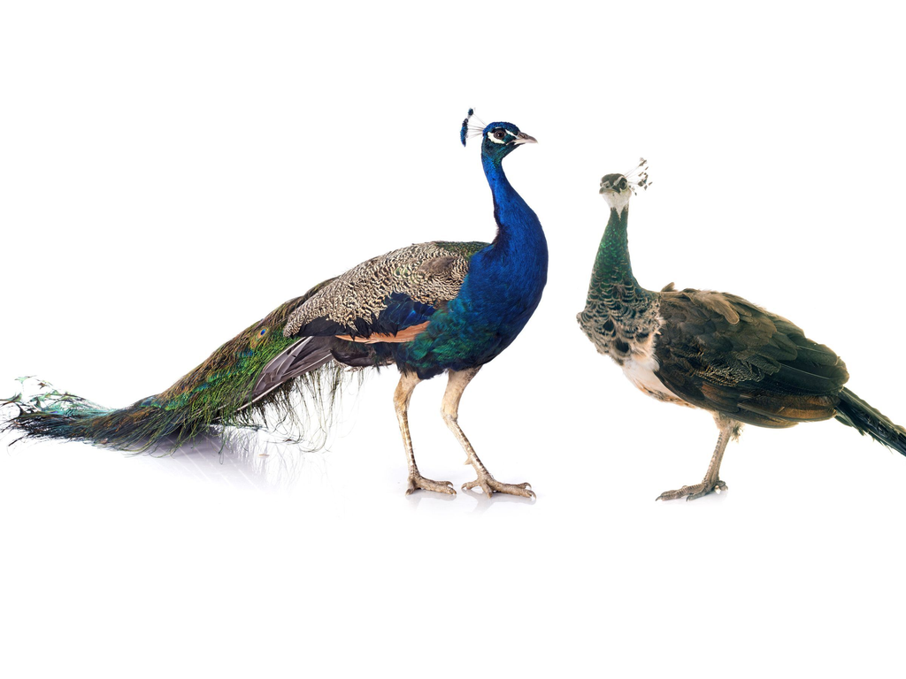

Image from ThoughtCo..

**Questions**

*Why do you think this phenomenon happens?*

*Why are females generally more drab?*

*In which instance to you think females would be more ornate than males? Can you think of some examples?*

To determine if **sexual dimorphism** exists in this tree swallow data were will get you to explore the average size measurements taken for each bird. Since birds were tracked using a band number, and birds may have been captured multiple times throughout their life, so we will observe the differences in average size measurement taken for each bird.

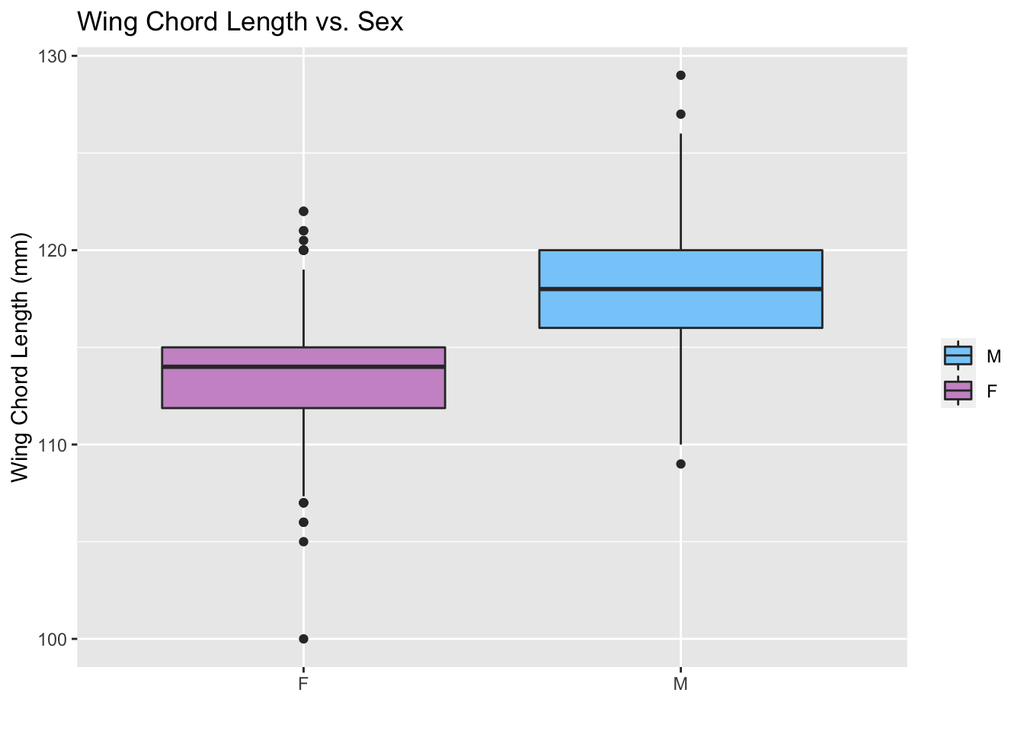

```r
# look at the following variable to see how they differ by gender : wing_chord, tail, and weight
# will will take the mean of these measurements by band_number and gender
wing_chord <- aggregate(wing_chord ~ band_number + sex, banding, mean)
# Boxplot of these trends based on sex
ggplot(wing_chord, aes(factor(sex), wing_chord, fill=sex)) +
  geom_boxplot() +
  scale_fill_manual("", values=c("M"= "lightskyblue", "F"= "plum3")) +
  xlab('') +
  ylab('Wing Chord Length (mm)') +
  ggtitle("Wing Chord Length vs. Sex")
```

Nice job! It looks like there is a difference between males and females in terms of wing chord measurements. Before moving forward, try measuring tail length and weight on your own. You’ll see we have included what your graphs *should* look like below for both tail and weight means by sex.

**Hint** Look at the example we just ran using the **aggregate** function first, then plot with **ggplot**.

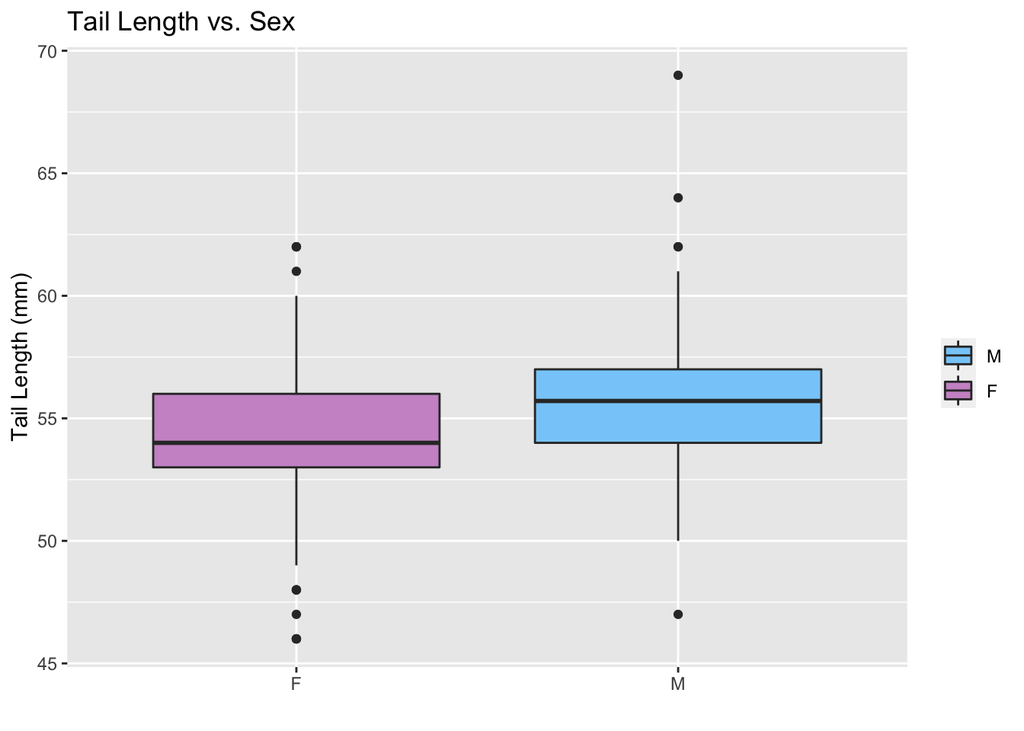

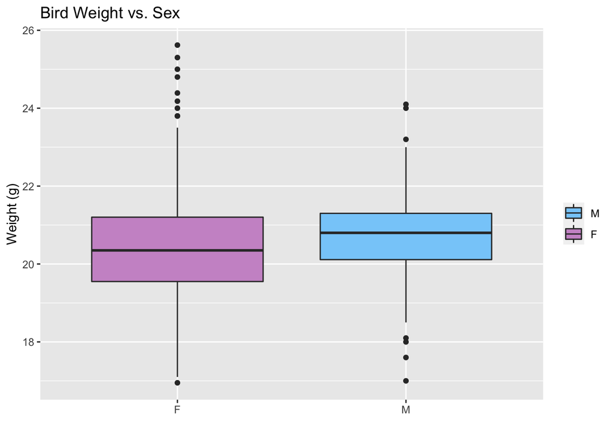

Now, to get a sense of how much the wind chord length, tail length, and weight differs between male and female tree swallows lets find the mean value for each.

```r
# can calculate the mean female and male wing flat length like this (using aggregate()) or could subset by sex and then calculate
wing_chord.avg <- aggregate(wing_chord ~ sex, wing_chord, mean)
wing_chord.avg
```

```
##   sex wing_chord
## 1   F   113.5396
## 2   M   117.9625
```

Calculate the tail and weight average on your own. Cross reference your calculations with the ones below.

```
##   sex     tail
## 1   F 54.26951
## 2   M 55.69233
```

```
##   sex   weight
## 1   F 20.46923
## 2   M 20.72255
```

Before we head to our next section, check out this ornate mating dance between males and female birds of paradise. Note the sexual dimorphism between the males and females!

[video not shown]

**Questions**

*What is the average wing chord length, tail length, and weight of the male tree swallows?*

*What is the average wing chord length, tail length, and weight of the female tree swallows?*

*Do these findings suggest that there is some level of sexual dimorphism in tree swallows?*

*What type of pressures could lead to sexual dimorphism in tree swallows?*